# DSC540 Project ML

Depaul University  
Group 8: Thejus Kannoth , Abhenai moola , Mounika Munigala  
Chicago, IL

### Project Description

In this project we will be analyzing insurance charges based on the provided features.

Data Source: https://www.kaggle.com/datasets/mirichoi0218/insurance

**Variable Information:**

age: Age of the primary beneficiary

sex: Gender of the primary beneficiary (male/female)

bmi: Body mass index, a measure of body fat based on height and weight

children: Number of children/dependents covered by health insurance

smoker: Whether the beneficiary is a smoker (yes/no)

region: The beneficiary's residential area in the US (northeast, southeast, southwest, northwest)

charges: Individual medical costs billed by health insurance

### Import Libraries

```python
import pandas as pd
import numpy as np
import seaborn as sns
import matplotlib.pyplot as plt

from sklearn.model_selection import train_test_split
from sklearn.linear_model import LinearRegression
from sklearn.tree import DecisionTreeRegressor
from sklearn.ensemble import RandomForestRegressor, GradientBoostingRegressor
from sklearn.metrics import r2_score, mean_squared_error
from sklearn.model_selection import GridSearchCV
```

#### Get the data

```python
# Load the dataset

df = pd.read_csv('insurance.csv')
```

```python
# Check the number of rows and columns
print("Number of rows and columns:", df.shape)
```

```
Number of rows and columns: (1338, 7)
```

The dataset contains comprehensive information about 1338 individuals across 7 attributes.

```python
# Display the first few rows of the dataset
df.head()
```

|  | age | sex | bmi | children | smoker | region | charges |
| --- | --- | --- | --- | --- | --- | --- | --- |
| 0 | 19 | female | 27.900 | 0 | yes | southwest | 16884.92400 |
| 1 | 18 | male | 33.770 | 1 | no | southeast | 1725.55230 |
| 2 | 28 | male | 33.000 | 3 | no | southeast | 4449.46200 |
| 3 | 33 | male | 22.705 | 0 | no | northwest | 21984.47061 |
| 4 | 32 | male | 28.880 | 0 | no | northwest | 3866.85520 |

#### Checking missing data

```python
# Check for missing values
df.isnull().sum()
```

```
age         0
sex         0
bmi         0
children    0
smoker      0
region      0
charges     0
dtype: int64
```

#### Categorical variables

```python
# Encoding categorical variables
df = pd.get_dummies(df, columns=['sex', 'smoker', 'region'], drop_first=True)
```

```python
df.head()
```

|  | age | bmi | children | charges | sex_male | smoker_yes | region_northwest | region_southeast | region_southwest |
| --- | --- | --- | --- | --- | --- | --- | --- | --- | --- |
| 0 | 19 | 27.900 | 0 | 16884.92400 | False | True | False | False | True |
| 1 | 18 | 33.770 | 1 | 1725.55230 | True | False | False | True | False |
| 2 | 28 | 33.000 | 3 | 4449.46200 | True | False | False | True | False |
| 3 | 33 | 22.705 | 0 | 21984.47061 | True | False | True | False | False |
| 4 | 32 | 28.880 | 0 | 3866.85520 | True | False | True | False | False |

#### Exploratory Data Analysis (EDA)

##### Summary statistics

```python
# Summary statistics
df.describe()
```

|  | age | bmi | children | charges |
| --- | --- | --- | --- | --- |
| count | 1338.000000 | 1338.000000 | 1338.000000 | 1338.000000 |
| mean | 39.207025 | 30.663397 | 1.094918 | 13270.422265 |
| std | 14.049960 | 6.098187 | 1.205493 | 12110.011237 |
| min | 18.000000 | 15.960000 | 0.000000 | 1121.873900 |
| 25% | 27.000000 | 26.296250 | 0.000000 | 4740.287150 |
| 50% | 39.000000 | 30.400000 | 1.000000 | 9382.033000 |
| 75% | 51.000000 | 34.693750 | 2.000000 | 16639.912515 |
| max | 64.000000 | 53.130000 | 5.000000 | 63770.428010 |

##### Distribution of Numerical Features Using histogram

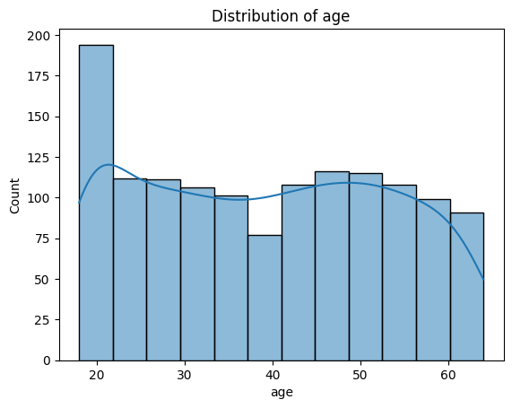

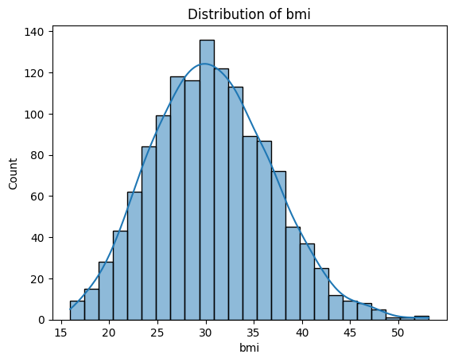

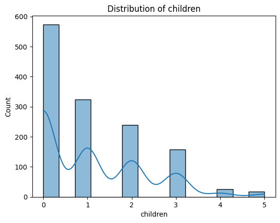

```python
numerical_features = ['age', 'bmi', 'children']
# Distribution plots
for column in numerical_features:
    sns.histplot(df[column], kde=True)
    plt.title(f'Distribution of {column}')
    plt.show()
```

#### Correlation map between the variables

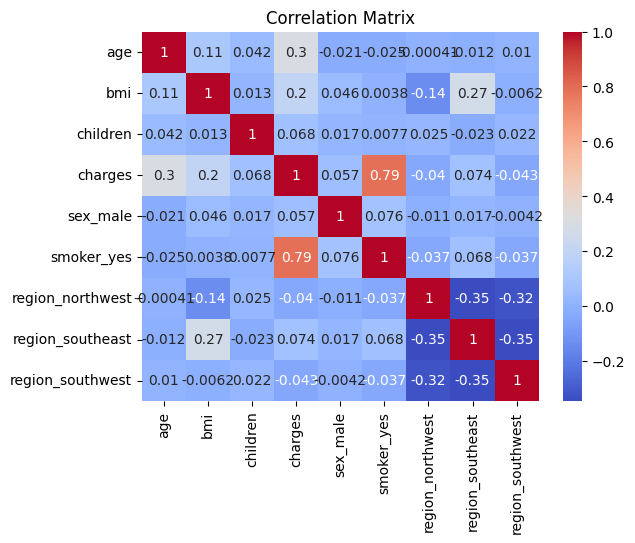

```python
# Correlation matrix
correlation_matrix = df.corr()
sns.heatmap(correlation_matrix, annot=True, cmap='coolwarm')
plt.title('Correlation Matrix')
plt.show()
```

Strong correlations include 'smoker_yes' with 'charges' (0.79) and 'age' with 'charges' (0.3), indicating smokers and older individuals tend to have higher charges. Most other correlations are weak, with values close to 0, indicating minimal relationships.

### Bar plots for categorical variables

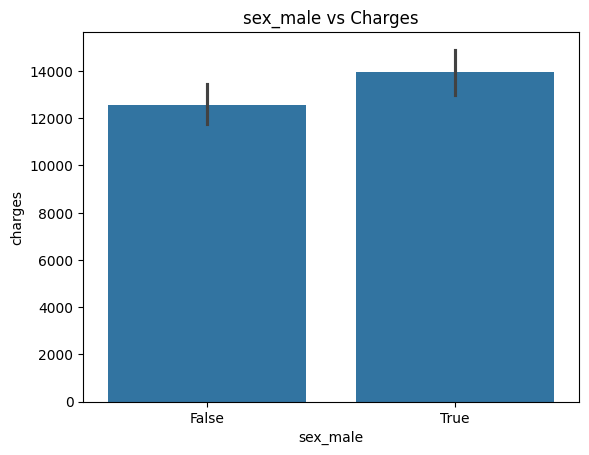

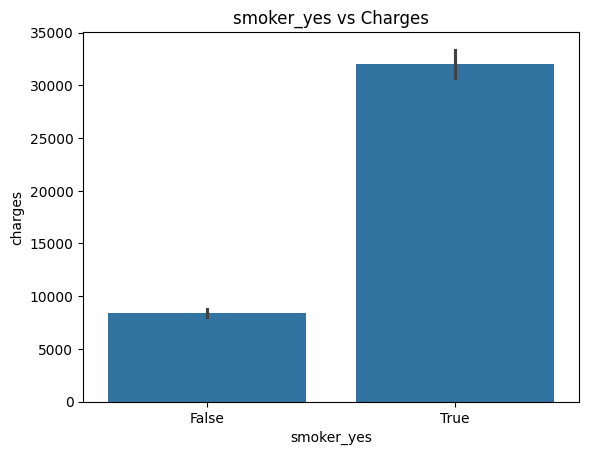

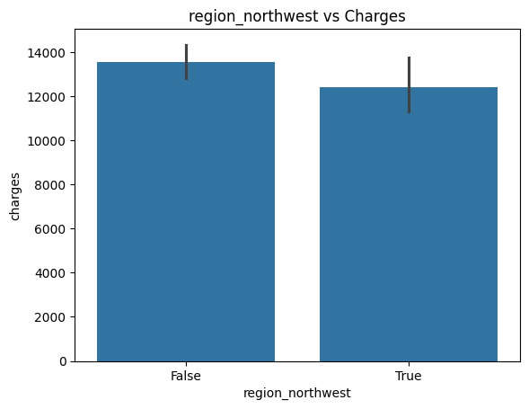

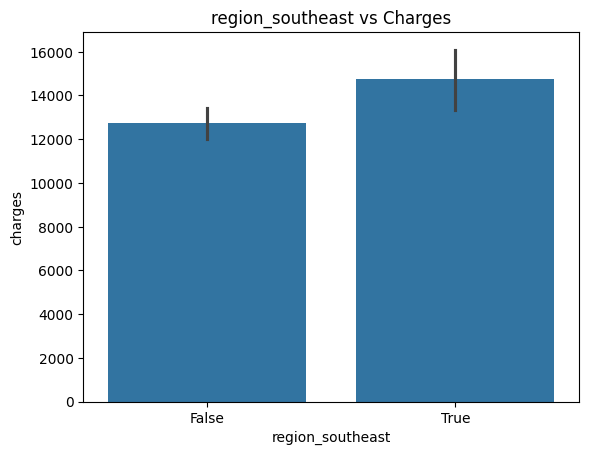

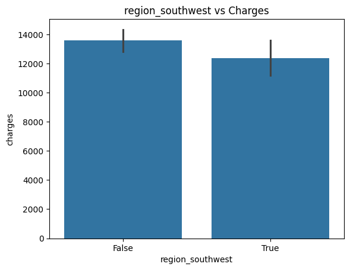

```python
# Bar plots for categorical variables
categorical_features = ['sex_male', 'smoker_yes', 'region_northwest', 'region_southeast', 'region_southwest']
for column in categorical_features:
    sns.barplot(x=df[column], y=df['charges'])
    plt.title(f'{column} vs Charges')
    plt.show()
```

Smoker_yes vs Charges graph shows a significant difference in the charges between smokers and non-smokers. Smokers have substantially higher charges compared to non-smokers, highlighting the impact of smoking on medical costs. This is a crucial finding for the insurance dataset, as it directly correlates smoking habits with increased healthcare expenses, which can influence insurance premium calculations and risk assessments.

### Joint plot of Age vs Charges

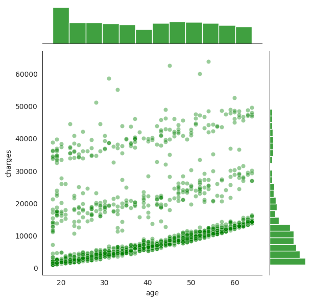

```python
# Set the plot style
sns.set_style('white')

# Create a jointplot
sns.jointplot(x='age', y='charges', data=df, kind='scatter', color='green', alpha=0.4)

# Show the plot
plt.show()
```

The scatter plot indicates a positive relationship between age and medical charges, where higher ages tend to be associated with higher medical charges. The marginal histograms provide additional insights into the distribution of the individual variables. The distribution of age is relatively uniform across most age groups, with a higher count of younger individuals. The charges histogram shows a right-skewed distribution, indicating that while most individuals incur lower charges, a smaller number of individuals have significantly higher medical charges.

### Prepare data for machine learning

```python
# Split the data
X = df.drop('charges', axis=1)
y = df['charges']

X_train, X_test, y_train, y_test = train_test_split(X, y, test_size=0.2, random_state=42)
X_train, X_val, y_train, y_val = train_test_split(X_train, y_train, test_size=0.25, random_state=42) # 0.25 x 0.8 = 0.2
```

```python
# Define a function to evaluate the model
def evaluate_model(model, X_train, y_train, X_val, y_val):
    model.fit(X_train, y_train)
    y_train_pred = model.predict(X_train)
    y_val_pred = model.predict(X_val)
    r2_train = r2_score(y_train, y_train_pred)
    rmse_train = mean_squared_error(y_train, y_train_pred, squared=False)
    r2_val = r2_score(y_val, y_val_pred)
    rmse_val = mean_squared_error(y_val, y_val_pred, squared=False)
    return r2_train, rmse_train, r2_val, rmse_val
```

### Machine Learning Models

#### 1. Linear Regression Model

```python
# Linear Regression
lr = LinearRegression()
r2_train_lr, rmse_train_lr, r2_val_lr, rmse_val_lr = evaluate_model(lr, X_train, y_train, X_val, y_val)
print(f"Linear Regression R^2 on training data: {r2_train_lr}")
print(f"Linear Regression RMSE on training data: {rmse_train_lr}")
print(f"Linear Regression R^2 on validation data: {r2_val_lr}")
print(f"Linear Regression RMSE on validation data: {rmse_val_lr}")
```

```
Linear Regression R^2 on training data: 0.7456575125269083
Linear Regression RMSE on training data: 5878.650180904848
Linear Regression R^2 on validation data: 0.728290784615923
Linear Regression RMSE on validation data: 6766.880761122626
```

#### 2. Decision Tree Model

```python
# Decision Tree Regressor
dt = DecisionTreeRegressor(random_state=42)
r2_train_dt, rmse_train_dt, r2_val_dt, rmse_val_dt = evaluate_model(dt, X_train, y_train, X_val, y_val)
print(f"Decision Tree R^2 on training data: {r2_train_dt}")
print(f"Decision Tree RMSE on training data: {rmse_train_dt}")
print(f"Decision Tree R^2 on validation data: {r2_val_dt}")
print(f"Decision Tree RMSE on validation data: {rmse_val_dt}")
```

```
Decision Tree R^2 on training data: 0.9992829261718845
Decision Tree RMSE on training data: 312.140481703273
Decision Tree R^2 on validation data: 0.7139761685891693
Decision Tree RMSE on validation data: 6942.84467978205
```

#### 3. Random Forest regression Model

```python
# Random Forest Regressor
rf = RandomForestRegressor(n_estimators=100, random_state=42)
r2_train_rf, rmse_train_rf, r2_val_rf, rmse_val_rf = evaluate_model(rf, X_train, y_train, X_val, y_val)
print(f"Random Forest R^2 on training data: {r2_train_rf}")
print(f"Random Forest RMSE on training data: {rmse_train_rf}")
print(f"Random Forest R^2 on validation data: {r2_val_rf}")
print(f"Random Forest RMSE on validation data: {rmse_val_rf}")
```

```
Random Forest R^2 on training data: 0.9766143498963663
Random Forest RMSE on training data: 1782.554775751991
Random Forest R^2 on validation data: 0.8171838928913253
Random Forest RMSE on validation data: 5550.646480727558
```

#### 4. Gradient Boosting Regression Model

```python
# Gradient Boosting Regressor
gbr = GradientBoostingRegressor(random_state=42)
r2_train_gbr, rmse_train_gbr, r2_val_gbr, rmse_val_gbr = evaluate_model(gbr, X_train, y_train, X_val, y_val)
print(f"Gradient Boosting R^2 on training data: {r2_train_gbr}")
print(f"Gradient Boosting RMSE on training data: {rmse_train_gbr}")
print(f"Gradient Boosting R^2 on validation data: {r2_val_gbr}")
print(f"Gradient Boosting RMSE on validation data: {rmse_val_gbr}")
```

```
Gradient Boosting R^2 on training data: 0.9151399572937297
Gradient Boosting RMSE on training data: 3395.6254765784215
Gradient Boosting R^2 on validation data: 0.828343741753384
Gradient Boosting RMSE on validation data: 5378.56176801043
```

### Model Optimization

Optimizing each model using grid search.

#### Optimizing Decision Tree Model

```python
# Define the parameter grid
param_grid_dt = {
    'max_depth': [None, 10, 20, 30],
    'min_samples_split': [2, 5, 10],
    'min_samples_leaf': [1, 2, 4],
    'max_features': [None, 'auto', 'sqrt', 'log2']
}

# Use GridSearchCV to find the best hyperparameters
grid_search_dt = GridSearchCV(estimator=dt, param_grid=param_grid_dt, cv=3, scoring='neg_mean_squared_error', n_jobs=-1, verbose=2)
grid_search_dt.fit(X_train, y_train)

# Get the best estimator
best_dt = grid_search_dt.best_estimator_

# Train the best model on the training data
best_dt.fit(X_train, y_train)
y_train_pred_best_dt = best_dt.predict(X_train)
y_val_pred_best_dt = best_dt.predict(X_val)

# Calculate R^2 and RMSE for the training data
r2_train_best_dt = r2_score(y_train, y_train_pred_best_dt)
rmse_train_best_dt = mean_squared_error(y_train, y_train_pred_best_dt, squared=False)

# Calculate R^2 and RMSE for the validation data
r2_val_best_dt = r2_score(y_val, y_val_pred_best_dt)
rmse_val_best_dt = mean_squared_error(y_val, y_val_pred_best_dt, squared=False)

print(f"Optimized Decision Tree R^2 on training data: {r2_train_best_dt}")
print(f"Optimized Decision Tree RMSE on training data: {rmse_train_best_dt}")
print(f"Optimized Decision Tree R^2 on validation data: {r2_val_best_dt}")
print(f"Optimized Decision Tree RMSE on validation data: {rmse_val_best_dt}")
```

```
Fitting 3 folds for each of 144 candidates, totalling 432 fits
Optimized Decision Tree R^2 on training data: 0.8992694666271142
Optimized Decision Tree RMSE on training data: 3699.5485166108974
Optimized Decision Tree R^2 on validation data: 0.8062574551527777
Optimized Decision Tree RMSE on validation data: 5714.113198950323
```

#### Optimizing Random Forest Model

```python
# Grid Search for Random Forest
param_grid_rf = {
    'n_estimators': [50, 100, 200],
    'max_depth': [None, 10, 20, 30],
    'min_samples_split': [2, 5, 10]
}

grid_search_rf = GridSearchCV(estimator=rf, param_grid=param_grid_rf, cv=3, scoring='neg_mean_squared_error', n_jobs=-1, verbose=2)
grid_search_rf.fit(X_train, y_train)
best_rf = grid_search_rf.best_estimator_
r2_train_best_rf, rmse_train_best_rf, r2_val_best_rf, rmse_val_best_rf = evaluate_model(best_rf, X_train, y_train, X_val, y_val)
print(f"Optimized Random Forest R^2 on training data: {r2_train_best_rf}")
print(f"Optimized Random Forest RMSE on training data: {rmse_train_best_rf}")
print(f"Optimized Random Forest R^2 on validation data: {r2_val_best_rf}")
print(f"Optimized Random Forest RMSE on validation data: {rmse_val_best_rf}")
```

```
Fitting 3 folds for each of 36 candidates, totalling 108 fits
Optimized Random Forest R^2 on training data: 0.9277987932827225
Optimized Random Forest RMSE on training data: 3132.134392863991
Optimized Random Forest R^2 on validation data: 0.8242466894043513
Optimized Random Forest RMSE on validation data: 5442.370412278682
```

#### Optimizing Gradient Boosting Model

```python
# Grid Search for Gradient Boosting
param_grid_gbr = {
    'n_estimators': [50, 100, 200],
    'learning_rate': [0.01, 0.1, 0.2],
    'max_depth': [3, 4, 5]
}

grid_search_gbr = GridSearchCV(estimator=gbr, param_grid=param_grid_gbr, cv=3, scoring='neg_mean_squared_error', n_jobs=-1, verbose=2)
grid_search_gbr.fit(X_train, y_train)
best_gbr = grid_search_gbr.best_estimator_
r2_train_best_gbr, rmse_train_best_gbr, r2_val_best_gbr, rmse_val_best_gbr = evaluate_model(best_gbr, X_train, y_train, X_val, y_val)
print(f"Optimized Gradient Boosting R^2 on training data: {r2_train_best_gbr}")
print(f"Optimized Gradient Boosting RMSE on training data: {rmse_train_best_gbr}")
print(f"Optimized Gradient Boosting R^2 on validation data: {r2_val_best_gbr}")
print(f"Optimized Gradient Boosting RMSE on validation data: {rmse_val_best_gbr}")
```

```
Fitting 3 folds for each of 27 candidates, totalling 81 fits
Optimized Gradient Boosting R^2 on training data: 0.8943662024933756
Optimized Gradient Boosting RMSE on training data: 3788.520196079363
Optimized Gradient Boosting R^2 on validation data: 0.8304163967942253
Optimized Gradient Boosting RMSE on validation data: 5345.991562929424
```

### Model Evaluation

Based on the validation R² and RMSE scores, the top 2 models are:

1. Optimized Gradient Boosting
2. Optimized Random Forest

Evaluating these models on test set.

```python
# Train and evaluate Random Forest Regressor
y_test_pred_rf = best_rf.predict(X_test)
r2_test_rf = r2_score(y_test, y_test_pred_rf)
rmse_test_rf = np.sqrt(mean_squared_error(y_test, y_test_pred_rf))

print("Random Forest Regressor - Test Data")
print(f"R^2: {r2_test_rf}")
print(f"RMSE: {rmse_test_rf}")

y_test_pred_gbr = best_gbr.predict(X_test)
r2_test_gbr = r2_score(y_test, y_test_pred_gbr)
rmse_test_gbr = np.sqrt(mean_squared_error(y_test, y_test_pred_gbr))

print("Gradient Boosting Regressor - Test Data")
print(f"R^2: {r2_test_gbr}")
print(f"RMSE: {rmse_test_gbr}")

# Summarize results in a DataFrame
regression_results = pd.DataFrame({
    'Model': ['Random Forest Regressor', 'Gradient Boosting Regressor'],
    'R^2': [r2_test_rf, r2_test_gbr],
    'RMSE': [rmse_test_rf, rmse_test_gbr]
})

print("Regression Results:")
print(regression_results)
```

```
Random Forest Regressor - Test Data
R^2: 0.8724980400908603
RMSE: 4449.103003820983
Gradient Boosting Regressor - Test Data
R^2: 0.8774735328982252
RMSE: 4361.4307963922865
Regression Results:
                         Model       R^2         RMSE
0      Random Forest Regressor  0.872498  4449.103004
1  Gradient Boosting Regressor  0.877474  4361.430796
```

The test set results show that the Gradient Boosting Regressor works better than the Random Forest Regressor, with a somewhat higher R^2 value (0.8775) and a lower RMSE (4361.43). Both models exhibit strong performance, suggesting that they successfully identify the underlying patterns in the data. Nonetheless, the Gradient Boosting Regressor exhibits a somewhat superior fit and accuracy of prediction. The Gradient Boosting Regressor is the optimal model for this regression challenge, according to the assessment metrics.

### Improving Model Performance

Another effective technique to improve model performance is Feature Engineering. This involves creating new features or modifying existing ones to better capture the underlying patterns in the data.

```python
from sklearn.preprocessing import PolynomialFeatures
from sklearn.pipeline import make_pipeline

# Create polynomial features
poly = PolynomialFeatures(degree=2, include_bias=False)

# Create a pipeline that includes polynomial feature transformation and the Gradient Boosting Regressor
model_pipeline = make_pipeline(poly, GradientBoostingRegressor(n_estimators=100, learning_rate=0.1, random_state=42))

# Fit the model pipeline
model_pipeline.fit(X_train, y_train)

# Evaluate the model pipeline on the test data
y_test_pred_poly = model_pipeline.predict(X_test)
r2_test_poly = r2_score(y_test, y_test_pred_poly)
rmse_test_poly = np.sqrt(mean_squared_error(y_test, y_test_pred_poly))

print("Gradient Boosting Regressor with Polynomial Features - Test Data")
print(f"R^2: {r2_test_poly}")
print(f"RMSE: {rmse_test_poly}")

# Summarize results in a DataFrame
regression_results_poly = pd.DataFrame({
    'Model': ['Gradient Boosting  with Polynomial Features'],
    'R^2': [r2_test_poly],
    'RMSE': [rmse_test_poly]
})

print("Regression Results:")
print(regression_results_poly)
```

```
Gradient Boosting Regressor with Polynomial Features - Test Data
R^2: 0.8694902464078844
RMSE: 4501.274674187287
Regression Results:
                                         Model      R^2         RMSE
0  Gradient Boosting  with Polynomial Features  0.86949  4501.274674
```

The addition of polynomial features in this case did not improve the performance of the Gradient Boosting Regressor. The model's R^2 value slightly decreased, and the RMSE increased compared to the original Gradient Boosting Regressor without polynomial features.

Implementing model stacking or blending, combining the predictions of multiple models to improve overall performance.

```python
from sklearn.ensemble import StackingRegressor
from sklearn.linear_model import RidgeCV
from sklearn.svm import SVR

# Define base models
base_models = [
    ('rf', RandomForestRegressor(n_estimators=100, random_state=42)),
    ('gbr', GradientBoostingRegressor(n_estimators=100, learning_rate=0.1, random_state=42))
]

# Define the meta-model
meta_model = RidgeCV()

# Create the stacking model
stacking_regressor = StackingRegressor(estimators=base_models, final_estimator=meta_model, cv=5)

# Fit the stacking model
stacking_regressor.fit(X_train, y_train)

# Evaluate the stacking model on the test data
y_test_pred_stack = stacking_regressor.predict(X_test)
r2_test_stack = r2_score(y_test, y_test_pred_stack)
rmse_test_stack = np.sqrt(mean_squared_error(y_test, y_test_pred_stack))

print("Stacking Regressor - Test Data")
print(f"R^2: {r2_test_stack}")
print(f"RMSE: {rmse_test_stack}")

# Summarize results in a DataFrame
regression_results_stack = pd.DataFrame({
    'Model': ['Stacking Regressor'],
    'R^2': [r2_test_stack],
    'RMSE': [rmse_test_stack]
})

print("Regression Results:")
print(regression_results_stack)
```

```
Stacking Regressor - Test Data
R^2: 0.8769717501653856
RMSE: 4370.352357016178
Regression Results:
                Model       R^2         RMSE
0  Stacking Regressor  0.876972  4370.352357
```

The stacking model achieved an R^2 value of 0.8770 and an RMSE of 4370.35 on the test data. This is very close to the performance of the original Gradient Boosting Regressor.

#### **Final Findings**

- The Gradient Boosting Regressor performed the best overall.
- Feature engineering with polynomial features did not improve the model.
- Stacking multiple models provided a similar level of performance to the best individual model.